# Regional Statistics

This code is to look at regional statistics, and figures and stats will end up in supplement.

```r
library(data.table)
library(ggplot2)
library(sf)
library(rgeos)
library(concaveman)
library(raster)
library(stringr)


#raw data
FishGlob_clean <- readRDS(here::here("data", "cleaned", "FishGlob.wellsampledyearscells_complete.final.rds"))

#model coefficients from year_dissimilarity_models.Rmd
model_coefs_reduced_length.unique <- readRDS(here::here("output","region_stats","model_coefs_reduced_length.unique.Rds"))

#NB: years sampled = last_year-first_year+1
```

*Additional cleaning (first written in “dissim_metric_space_time.Rmd”)*

Delete observations without CPUE except for MEDITS (we will do trends in abundance metrics for this region)

```r
#delete all rows where wgt_cpue is NA,  unless it is MEDITS region
FishGlob_clean.noNA <- FishGlob_clean[(survey != "MEDITS" & !is.na(wgt_cpue)) | survey == "MEDITS"]

#check
summary(FishGlob_clean.noNA[, wgt_cpue]) #why inf? 13 observations from GSL-N,  I will delete these
FishGlob_clean.noNA <- copy(FishGlob_clean.noNA)[!is.infinite(wgt_cpue), ]
```

Loop through all regions (takes a few hours to run)

```r
all_survey_units <- unique(FishGlob_clean.noNA[, survey_unit])
```

For NZ-CHAT, we want to lump December observations with next year of observations (January, February)

```r
FishGlob_clean.noNA[survey_unit == "NZ-CHAT" & month == 12,  year := year+1, ]
```

Some spp are duplicated within a haul. In all cases, this is due to verbatim names matching to a single accepted name. Therefore, we will sum these wgts and abundances

```r
FishGlob_clean.noNA[, wgt := sum(wgt,  na.rm = T), .(accepted_name,  haul_id)][,
                     wgt_h := sum(wgt_h,  na.rm = T), .(accepted_name,  haul_id)][,
                     wgt_cpue := sum(wgt_cpue,  na.rm = T), .(accepted_name,  haul_id)][,
                     num := sum(num,  na.rm = T), .(accepted_name,  haul_id)][,
                     num_h := sum(num_h,  na.rm = T), .(accepted_name,  haul_id)][,
                     num_cpue := sum(num_cpue,  na.rm = T), .(accepted_name,  haul_id)]

FishGlob_clean.noNA <- unique(FishGlob_clean.noNA[,.(survey, haul_id, country, sub_area, continent, stat_rec, station, stratum, year, month, day, quarter, season, latitude, longitude, haul_dur, area_swept, gear, depth, sbt, sst, num, num_h, num_cpue, wgt, wgt_h, wgt_cpue, verbatim_aphia_id, accepted_name, aphia_id, SpecCode, kingdom, phylum, class, order, family, genus, rank, survey_unit, years_sampled, cell_ID, cell_year_count, year_cell_count, years_sampled_update)])

#make depth numeric
FishGlob_clean.noNA[,depth := as.numeric(depth)]

#add column for yearly summed biomass (note that MEDITS doesn't have biomass, so it will be excluded from these plots)
FishGlob_clean.noNA[,wgt_cpue_annual := sum(wgt_cpue,na.rm = T),.(year, survey_unit)]

#add column for yearly summed # of hauls
FishGlob_clean.noNA[,haul_id_count_annual := uniqueN(haul_id),.(year, survey_unit)]
```

Pull in avg temp values and pull in avg fishing values

```r
 #open fishing and temp data
distances_dissimilarities_allyears.r.temp.fishing <- readRDS( here::here("output","distance_decay","distances_dissimilarities_allyears.r.temp.fishing.rds"))

distances_dissimilarities_allyears.r.temp.fishing[,mean_reg_temp_allyears := mean(sst_mean, na.rm = T),.(survey_unit)][,mean_reg_fishing_allyears := mean(summed_tonnes, na.rm = T),.(survey_unit)]


avg_temp_avg_fishing <- unique(distances_dissimilarities_allyears.r.temp.fishing[,.(survey_unit,mean_reg_fishing_allyears, mean_reg_temp_allyears)])

#link coefficients
year_survey_unit_characteristics <- model_coefs_reduced_length.unique[avg_temp_avg_fishing, on = "survey_unit"]
```

```r
#survey_unit
region_stats <- as.data.table(matrix(nrow = length(all_survey_units)))

region_stats[,survey_unit := as.character(V1)][, survey := as.character(V1)][, spp_num := as.numeric(V1)][,mean_annual_biomass := as.numeric()][,mean_haul_id_count_annual := as.numeric()][, study_period := as.numeric(V1)][, study_duration := as.numeric(V1)][, lat_range := as.numeric(V1)][, mid_lat := as.numeric(V1)][, lon_range := as.numeric(V1)][, area_km := as.numeric(V1)][, depth_range := as.numeric(V1)][,  mid_depth := as.numeric(V1)][, mean_temp := as.numeric(V1)][, mean_landings := as.numeric(V1)][,bray_coef := as.numeric()][,bray_coef_upr := as.numeric()][,bray_coef_lwr := as.numeric()][,direction_of_change := as.character()][,significant := as.logical()]

  region_stats[,V1:=NULL]

for (i in 1:length(all_survey_units)) {
  reduced_FishGlob_cleaned.10year <- FishGlob_clean.noNA[survey_unit == all_survey_units[i]]

    ####unique lat lon
    lat_lon <- unique(reduced_FishGlob_cleaned.10year[,.(latitude, longitude)])

    pts <- st_as_sf(lat_lon, coords=c('longitude','latitude'), crs=4326 )

    conc <- concaveman(pts)

    sf_use_s2(FALSE) #helps with spherical geometry
    area <- st_area(conc) #m2

    #compile into region_Stats table
                  region_stats[i,"survey_unit"] <- paste0(all_survey_units[i])
                  region_stats[i,"survey"] <- word(all_survey_units[i],1, sep = "_")
                  region_stats[i,"spp_num"] <- length(unique(reduced_FishGlob_cleaned.10year[,accepted_name]))
                  region_stats[i,"mean_annual_biomass"] <- mean(reduced_FishGlob_cleaned.10year[,wgt_cpue_annual])
                  region_stats[i,"mean_haul_id_count_annual"] <- mean(reduced_FishGlob_cleaned.10year[,haul_id_count_annual])
                  region_stats[i,"study_period"] <- max(reduced_FishGlob_cleaned.10year$year)-min(reduced_FishGlob_cleaned.10year$year)
                  region_stats[i,"study_duration"] <- length(unique(reduced_FishGlob_cleaned.10year$year))
                  region_stats[i,"lat_range"] <- max(reduced_FishGlob_cleaned.10year$latitude)-min(reduced_FishGlob_cleaned.10year$latitude)
                  region_stats[i,"mid_lat"] <- mean(reduced_FishGlob_cleaned.10year$latitude)
                  region_stats[i,"lon_range"] <- max(reduced_FishGlob_cleaned.10year$longitude)-min(reduced_FishGlob_cleaned.10year$longitude)
                  region_stats[i,"area_km"] <- area/(1000^2)
                  region_stats[i,"depth_range"] <- max(reduced_FishGlob_cleaned.10year$depth, na.rm = T)-min(reduced_FishGlob_cleaned.10year$depth, na.rm = T)
                  region_stats[i,"mid_depth"] <- mean(reduced_FishGlob_cleaned.10year$depth, na.rm = T)
                  region_stats[i,"mean_temp"] <- year_survey_unit_characteristics[survey_unit == all_survey_units[i],mean_reg_temp_allyears]
                  region_stats[i,"mean_landings"] <- year_survey_unit_characteristics[survey_unit == all_survey_units[i],mean_reg_fishing_allyears]
                  region_stats[i,"bray_coef"] <- year_survey_unit_characteristics[survey_unit == all_survey_units[i],year_adj]
                  region_stats[i,"bray_coef_lwr"] <- year_survey_unit_characteristics[survey_unit == all_survey_units[i],lwr]
                  region_stats[i,"bray_coef_upr"] <- year_survey_unit_characteristics[survey_unit == all_survey_units[i],upr]
                  region_stats[i,"Directional_Change"] <- year_survey_unit_characteristics[survey_unit == all_survey_units[i],Directional_Change]
                  region_stats[i,"significant"] <- year_survey_unit_characteristics[survey_unit == all_survey_units[i],significant]
}
#if any values are -Inf, change to NA
invisible(lapply(names(region_stats),function(.name) set(region_stats, which(is.infinite(region_stats[[.name]])), j = .name,value =NA)))

#add significant directions column
region_stats[,"Significant Trends" := ifelse(significant==T, Directional_Change, "No Directional Change")]

#add column for avg # of hauls per area
region_stats[,avg_hauls_area := mean_haul_id_count_annual/area_km]


saveRDS(region_stats, here::here("output","region_stats","region_stats.rds"))
```

PCA

```r
library(factoextra)
region_stats.naomit <- na.omit(region_stats, cols = c(3:13))
region_stats.descriptive<- data.frame(region_stats[,3:13])
rownames(region_stats.descriptive) <- region_stats$survey_unit
region_stats.pca <- prcomp(na.omit(region_stats.descriptive), center = TRUE,scale. = TRUE) #removes all rows with missing values

fviz_pca_ind(region_stats.pca,
             repel = TRUE     # Avoid text overlapping
             )

fviz_pca_biplot(region_stats.pca, repel = TRUE,
                col.var = "#2E9FDF", # Variables color
                col.ind = "#696969"  # Individuals color
                )

summary(region_stats.pca)

load.pca <- region_stats.pca$loadings
print(load.pca)

fviz_pca_var(region_stats.pca,
             col.var = "contrib", # Color by contributions to the PC
             gradient.cols = c("#00AFBB", "#E7B800", "#FC4E07"),
             repel = TRUE,     # Avoid text overlapping
             geom = c("arrow", "text")
             )

fviz_pca(region_stats.pca, label = c("var","ind"), repel = T, habillage = region_stats.naomit[,survey_unit], ggtheme = theme_classic())

fviz_pca(region_stats.pca, label = c("var","ind"), repel = T, habillage = region_stats.naomit[,jaccard_positive_negative_coef], ggtheme = theme_classic())

fviz_pca(region_stats.pca, label = c("ind"), repel = T, habillage = region_stats.naomit[,bray_positive_negative_coef], ggtheme = theme_classic())

fviz_pca(region_stats.pca, label = c("var"), repel = T, habillage = region_stats.naomit[,bray_positive_negative_coef], ggtheme = theme_classic())

fviz_pca(region_stats.pca, label = c("var","ind"), repel = T, habillage = region_stats.naomit[,bray_positive_negative_coef], ggtheme = theme_classic())
```

Check some linear models

```r
colnames(region_stats)
```

Regions that are differentiating tend to have lower overall gamma diversity than regions that are homogenizing

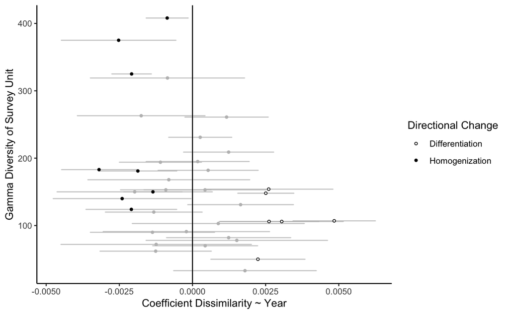

```r
spp_num_vs_coef <- ggplot() +
    geom_errorbar(data = region_stats, aes(x = spp_num, y = bray_coef, ymin = bray_coef_lwr, ymax = bray_coef_upr), color = "grey", alpha = 0.8, width = 0.5) + #add confidence intervals
    geom_point(data = region_stats[`Significant Trends` == "No Directional Change",], aes(x = spp_num , y = bray_coef), stat = 'identity', fill = "grey",color = "grey", shape = 21, size = 1) +
        geom_point(data = region_stats[`Significant Trends` != "No Directional Change",], aes(x = spp_num , y = bray_coef, fill = Directional_Change), stat = 'identity', shape = 21, color = "black", size = 1) +
    scale_fill_manual(values = c("white","black"), name = "Directional Change") +
  geom_hline(yintercept = 0, size = 0.5) +
  ylab("Coefficient Dissimilarity ~ Year") +
  xlab("Gamma Diversity of Survey Unit") +
  coord_flip() +
  theme_classic()

spp_num_vs_coef

ggsave(spp_num_vs_coef, path = here::here("figures","bray_coef_vs_survey_characteristics"), filename = "spp_num_vs_coef.jpg", height =7, width = 5, unit = "in")
```

More likely to detect both homogenization and differentation for longer study periods

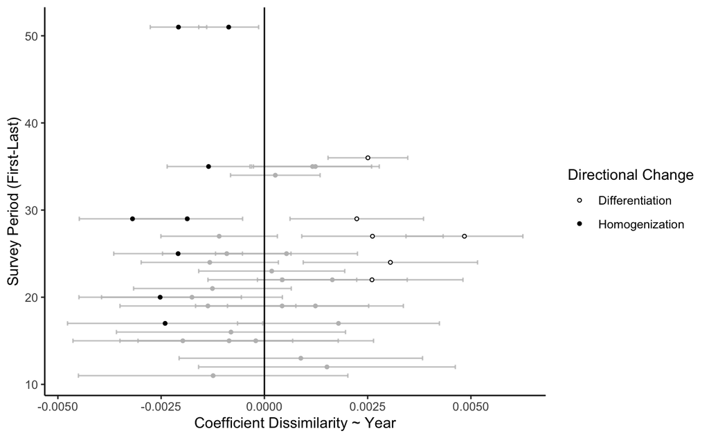

```r
study_period_vs_coef <- ggplot() +
    geom_errorbar(data = region_stats, aes(x = study_period, y = bray_coef, ymin = bray_coef_lwr, ymax = bray_coef_upr), color = "grey", alpha = 0.8, width = 0.5) + #add confidence intervals
    geom_point(data = region_stats[`Significant Trends` == "No Directional Change",], aes(x = study_period , y = bray_coef), stat = 'identity', fill = "grey",color = "grey", shape = 21, size = 1) +
        geom_point(data = region_stats[`Significant Trends` != "No Directional Change",], aes(x = study_period , y = bray_coef, fill = Directional_Change), stat = 'identity', shape = 21, color = "black", size = 1) +
    scale_fill_manual(values = c("white","black"), name = "Directional Change") +
  geom_hline(yintercept = 0, size = 0.5) +
  ylab("Coefficient Dissimilarity ~ Year") +
  xlab("Survey Period (First-Last)") +
  coord_flip() +
  theme_classic()

study_period_vs_coef

ggsave(study_period_vs_coef, path = here::here("figures","bray_coef_vs_survey_characteristics"), filename = "study_period_vs_coef.jpg", height =7, width = 5, unit = "in")
```

More likely to detect differentiation when fewer years are sampled and more likely to detect homogenization when more years are sampled

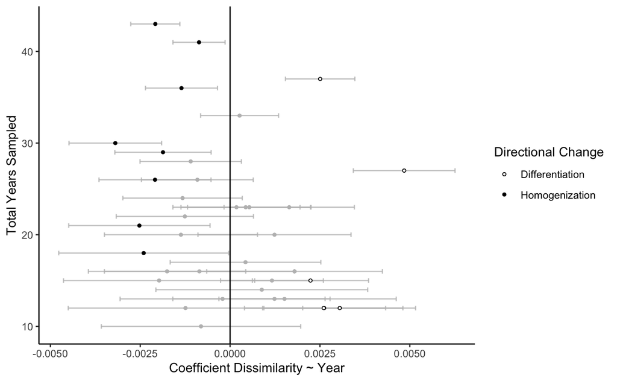

```r
study_duration_vs_coef <- ggplot() +
    geom_errorbar(data = region_stats, aes(x = study_duration, y = bray_coef, ymin = bray_coef_lwr, ymax = bray_coef_upr), color = "grey", alpha = 0.8, width = 0.5) + #add confidence intervals
    geom_point(data = region_stats[`Significant Trends` == "No Directional Change",], aes(x = study_duration , y = bray_coef), stat = 'identity', fill = "grey",color = "grey", shape = 21, size = 1) +
        geom_point(data = region_stats[`Significant Trends` != "No Directional Change",], aes(x = study_duration , y = bray_coef, fill = Directional_Change), stat = 'identity', shape = 21, color = "black", size = 1) +
    scale_fill_manual(values = c("white","black"), name = "Directional Change") +
  geom_hline(yintercept = 0, size = 0.5) +
  ylab("Coefficient Dissimilarity ~ Year") +
  xlab("Total Years Sampled") +
  coord_flip() +
  theme_classic()

study_duration_vs_coef

ggsave(study_duration_vs_coef, path = here::here("figures","bray_coef_vs_survey_characteristics"), filename = "study_duration_vs_coef.jpg", height =7, width = 5, unit = "in")
```

More likely to detect differentiation when a small latitudinal range is sampled, more likely to detect homogenization when a larger latitudinal range is sampled

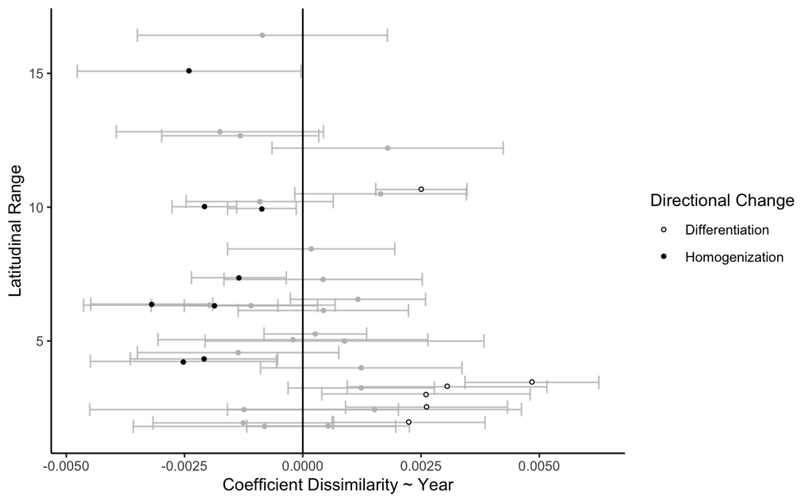

```r
lat_range_vs_coef <- ggplot() +
    geom_errorbar(data = region_stats, aes(x = lat_range, y = bray_coef, ymin = bray_coef_lwr, ymax = bray_coef_upr), color = "grey", alpha = 0.8, width = 0.5, position = "jitter") + #add confidence intervals
    geom_point(data = region_stats[`Significant Trends` == "No Directional Change",], aes(x = lat_range , y = bray_coef), stat = 'identity', fill = "grey",color = "grey", shape = 21, size = 1, position = "jitter") +
        geom_point(data = region_stats[`Significant Trends` != "No Directional Change",], aes(x = lat_range , y = bray_coef, fill = Directional_Change), stat = 'identity', shape = 21, color = "black", size = 1, position = "jitter") +
    scale_fill_manual(values = c("white","black"), name = "Directional Change") +
  geom_hline(yintercept = 0, size = 0.5) +
  ylab("Coefficient Dissimilarity ~ Year") +
  xlab("Latitudinal Range") +
  coord_flip() +
  theme_classic()

lat_range_vs_coef

ggsave(lat_range_vs_coef, path = here::here("figures","bray_coef_vs_survey_characteristics"), filename = "lat_range_vs_coef.jpg", height =7, width = 5, unit = "in")
```

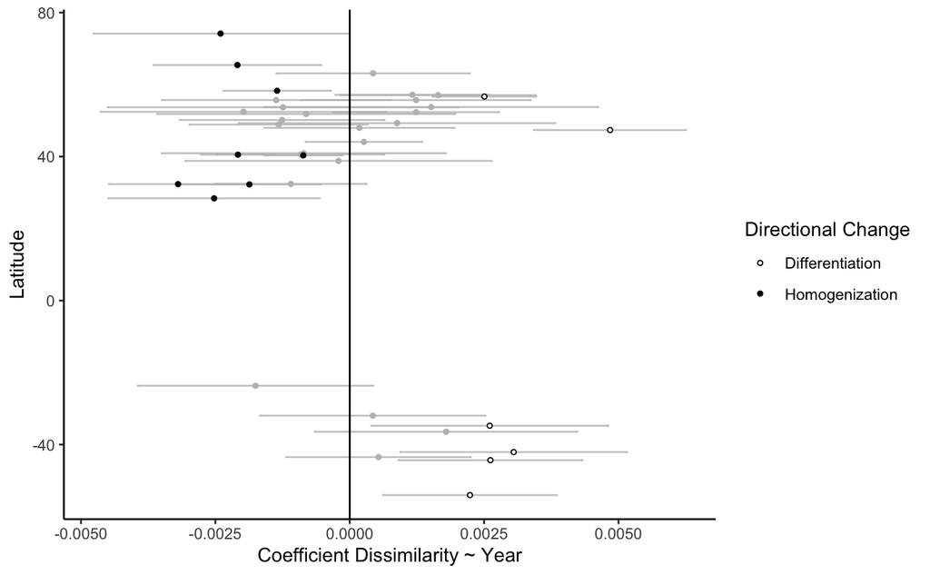

```r
mid_lat_vs_coef <- ggplot() +
    geom_errorbar(data = region_stats, aes(x = mid_lat, y = bray_coef, ymin = bray_coef_lwr, ymax = bray_coef_upr), color = "grey", alpha = 0.8, width = 0.5) + #add confidence intervals
    geom_point(data = region_stats[`Significant Trends` == "No Directional Change",], aes(x = mid_lat , y = bray_coef), stat = 'identity', fill = "grey",color = "grey", shape = 21, size = 1) +
        geom_point(data = region_stats[`Significant Trends` != "No Directional Change",], aes(x = mid_lat , y = bray_coef, fill = Directional_Change), stat = 'identity', shape = 21, color = "black", size = 1) +
    scale_fill_manual(values = c("white","black"), name = "Directional Change") +
  geom_hline(yintercept = 0, size = 0.5) +
  ylab("Coefficient Dissimilarity ~ Year") +
  xlab("Latitude") +
  coord_flip() +
  theme_classic()

mid_lat_vs_coef

ggsave(mid_lat_vs_coef, path = here::here("figures","bray_coef_vs_survey_characteristics"), filename = "mid_lat_vs_coef.jpg", height =7, width = 5, unit = "in")
```

#NEED TO FIX FOR REGIONS THAT CROSS DATE LINE

```r
ggplot(region_stats) +
  geom_boxplot(aes(x = `Significant Trends`, y = lon_range, group = `Significant Trends`)) +
  theme_classic()

ggplot(region_stats) +
  geom_point(aes(x = lon_range, y = bray_coef)) +
  theme_classic()
```

Areas that are differentiating tend to be smaller than areas that are homogenizing

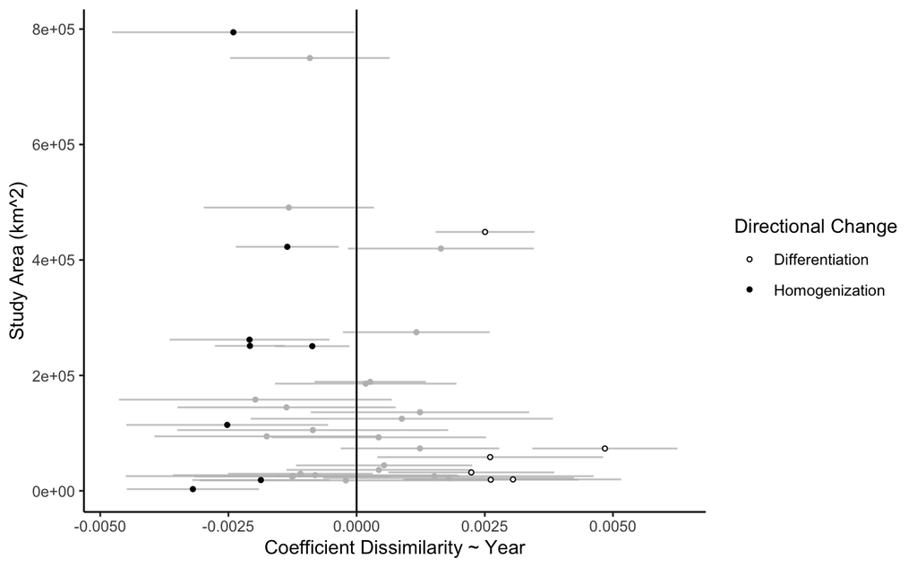

```r
area_vs_coef <- ggplot() +
    geom_errorbar(data = region_stats, aes(x = area_km, y = bray_coef, ymin = bray_coef_lwr, ymax = bray_coef_upr), color = "grey", alpha = 0.8, width = 0.5) + #add confidence intervals
    geom_point(data = region_stats[`Significant Trends` == "No Directional Change",], aes(x = area_km , y = bray_coef), stat = 'identity', fill = "grey",color = "grey", shape = 21, size = 1) +
        geom_point(data = region_stats[`Significant Trends` != "No Directional Change",], aes(x = area_km , y = bray_coef, fill = Directional_Change), stat = 'identity', shape = 21, color = "black", size = 1) +
    scale_fill_manual(values = c("white","black"), name = "Directional Change") +
  geom_hline(yintercept = 0, size = 0.5) +
  ylab("Coefficient Dissimilarity ~ Year") +
  xlab("Study Area (km^2)") +
  coord_flip() +
  theme_classic()

area_vs_coef

ggsave(area_vs_coef, path = here::here("figures","bray_coef_vs_survey_characteristics"), filename = "area_vs_coef.jpg", height =7, width = 5, unit = "in")
```

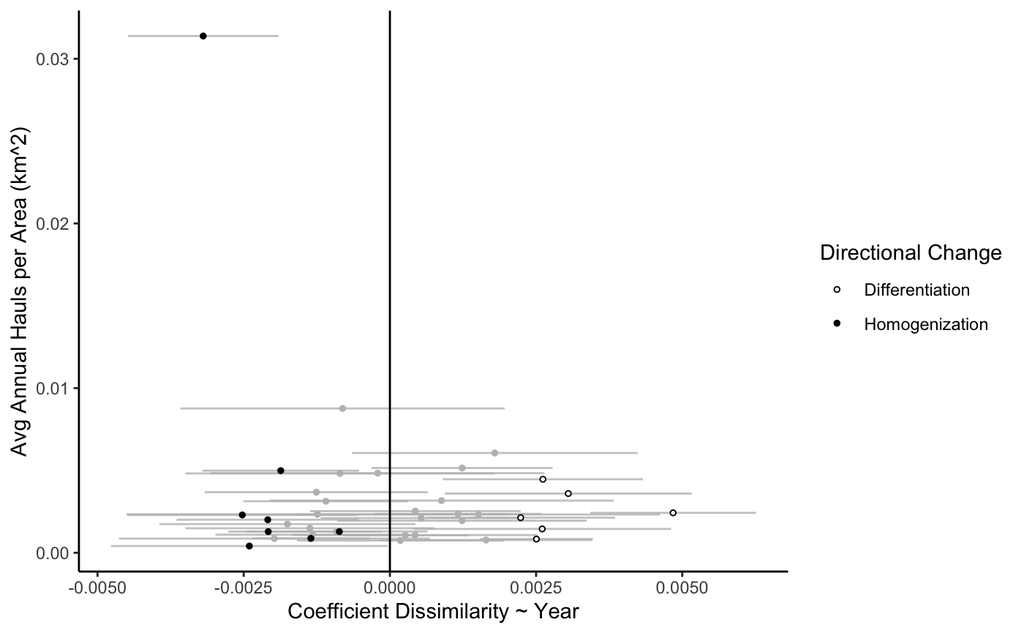

```r
avg_hauls_area_vs_coef <- ggplot() +
    geom_errorbar(data = region_stats, aes(x = avg_hauls_area, y = bray_coef, ymin = bray_coef_lwr, ymax = bray_coef_upr), color = "grey", alpha = 0.8) + #add confidence intervals
    geom_point(data = region_stats[`Significant Trends` == "No Directional Change",], aes(x = avg_hauls_area , y = bray_coef), stat = 'identity', fill = "grey",color = "grey", shape = 21, size = 1) +
        geom_point(data = region_stats[`Significant Trends` != "No Directional Change",], aes(x = avg_hauls_area , y = bray_coef, fill = Directional_Change), stat = 'identity', shape = 21, color = "black", size = 1) +
    scale_fill_manual(values = c("white","black"), name = "Directional Change") +
  geom_hline(yintercept = 0, size = 0.5) +
  ylab("Coefficient Dissimilarity ~ Year") +
  xlab("Avg Annual Hauls per Area (km^2)") +
  coord_flip() +
  theme_classic()

avg_hauls_area_vs_coef

ggsave(avg_hauls_area_vs_coef, path = here::here("figures","bray_coef_vs_survey_characteristics"), filename = "avg_hauls_area_vs_coef.jpg", height =7, width = 5, unit = "in")
```

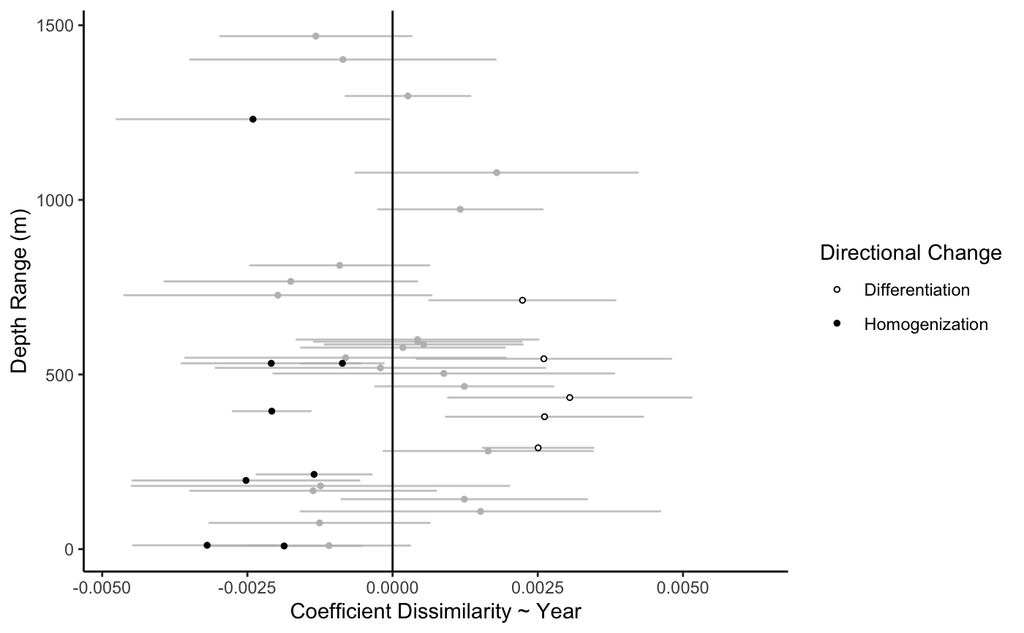

```r
depth_range_vs_coef <- ggplot() +
    geom_errorbar(data = region_stats, aes(x = depth_range, y = bray_coef, ymin = bray_coef_lwr, ymax = bray_coef_upr), color = "grey", alpha = 0.8, width = 0.5) + #add confidence intervals
    geom_point(data = region_stats[`Significant Trends` == "No Directional Change",], aes(x = depth_range , y = bray_coef), stat = 'identity', fill = "grey",color = "grey", shape = 21, size = 1) +
        geom_point(data = region_stats[`Significant Trends` != "No Directional Change",], aes(x = depth_range , y = bray_coef, fill = Directional_Change), stat = 'identity', shape = 21, color = "black", size = 1) +
    scale_fill_manual(values = c("white","black"), name = "Directional Change") +
  geom_hline(yintercept = 0, size = 0.5) +
  ylab("Coefficient Dissimilarity ~ Year") +
  xlab("Depth Range (m)") +
  coord_flip() +
  theme_classic()

depth_range_vs_coef

ggsave(depth_range_vs_coef, path = here::here("figures","bray_coef_vs_survey_characteristics"), filename = "depth_range_vs_coef.jpg", height =7, width = 5, unit = "in")
```

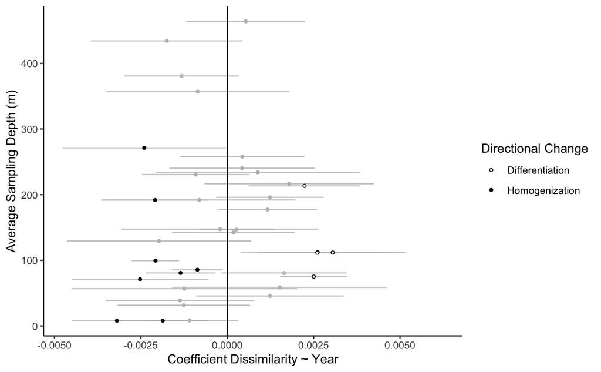

```r
mid_depth_vs_coef <- ggplot() +
    geom_errorbar(data = region_stats, aes(x = mid_depth, y = bray_coef, ymin = bray_coef_lwr, ymax = bray_coef_upr), color = "grey", alpha = 0.8, width = 0.5) + #add confidence intervals
    geom_point(data = region_stats[`Significant Trends` == "No Directional Change",], aes(x = mid_depth , y = bray_coef), stat = 'identity', fill = "grey",color = "grey", shape = 21, size = 1) +
        geom_point(data = region_stats[`Significant Trends` != "No Directional Change",], aes(x = mid_depth , y = bray_coef, fill = Directional_Change), stat = 'identity', shape = 21, color = "black", size = 1) +
    scale_fill_manual(values = c("white","black"), name = "Directional Change") +
  geom_hline(yintercept = 0, size = 0.5) +
  ylab("Coefficient Dissimilarity ~ Year") +
  xlab("Average Sampling Depth (m)") +
  coord_flip() +
  theme_classic()

mid_depth_vs_coef

ggsave(mid_depth_vs_coef, path = here::here("figures","bray_coef_vs_survey_characteristics"), filename = "mid_depth_vs_coef.jpg", height =7, width = 5, unit = "in")
```

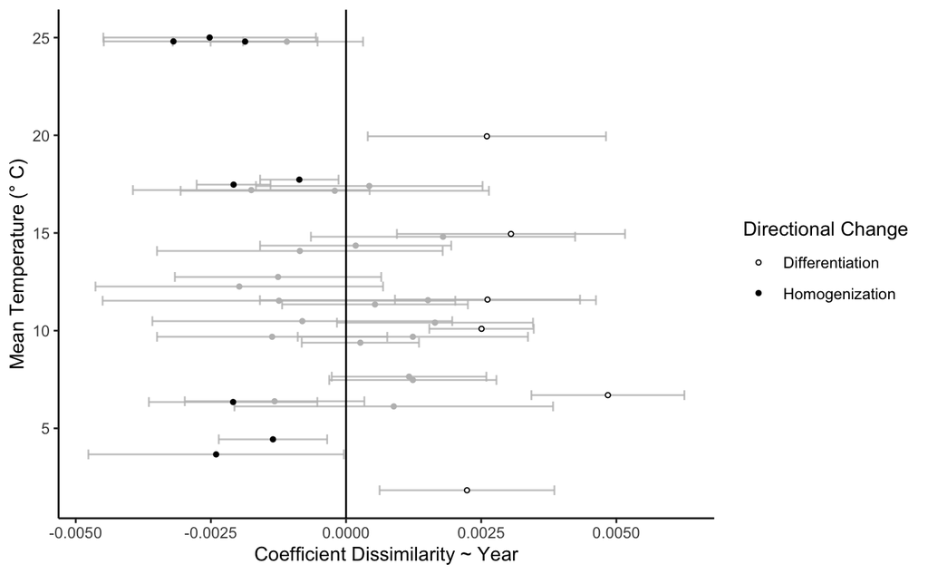

```r
mean_temp_vs_coef <- ggplot() +
    geom_errorbar(data = region_stats, aes(x = mean_temp, y = bray_coef, ymin = bray_coef_lwr, ymax = bray_coef_upr), color = "grey", alpha = 0.8, width = 0.5) + #add confidence intervals
    geom_point(data = region_stats[`Significant Trends` == "No Directional Change",], aes(x = mean_temp , y = bray_coef), stat = 'identity', fill = "grey",color = "grey", shape = 21, size = 1) +
        geom_point(data = region_stats[`Significant Trends` != "No Directional Change",], aes(x = mean_temp , y = bray_coef, fill = Directional_Change), stat = 'identity', shape = 21, color = "black", size = 1) +
    scale_fill_manual(values = c("white","black"), name = "Directional Change") +
  geom_hline(yintercept = 0, size = 0.5) +
  ylab("Coefficient Dissimilarity ~ Year") +
  xlab(paste0("Mean Temperature (","\u00B0"," C)")) +
  coord_flip() +
  theme_classic()

mean_temp_vs_coef

ggsave(mean_temp_vs_coef, path = here::here("figures","bray_coef_vs_survey_characteristics"), filename = "mean_temp_vs_coef.jpg", height =7, width = 5, unit = "in")
```

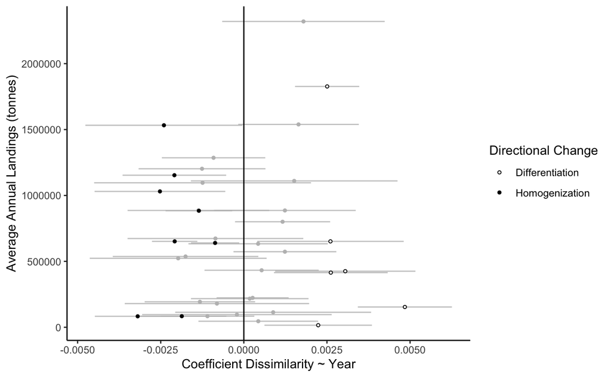

```r
mean_landings_vs_coef <- ggplot() +
    geom_errorbar(data = region_stats, aes(x = mean_landings, y = bray_coef, ymin = bray_coef_lwr, ymax = bray_coef_upr), color = "grey", alpha = 0.8, width = 0.5) + #add confidence intervals
    geom_point(data = region_stats[`Significant Trends` == "No Directional Change",], aes(x = mean_landings , y = bray_coef), stat = 'identity', fill = "grey",color = "grey", shape = 21, size = 1) +
        geom_point(data = region_stats[`Significant Trends` != "No Directional Change",], aes(x = mean_landings , y = bray_coef, fill = Directional_Change), stat = 'identity', shape = 21, color = "black", size = 1) +
    scale_fill_manual(values = c("white","black"), name = "Directional Change") +
  geom_hline(yintercept = 0, size = 0.5) +
  ylab("Coefficient Dissimilarity ~ Year") +
  xlab(paste0("Average Annual Landings (tonnes)")) +
  coord_flip() +
  theme_classic()

mean_landings_vs_coef

ggsave(mean_landings_vs_coef, path = here::here("figures","bray_coef_vs_survey_characteristics"), filename = "mean_landings_vs_coef.jpg", height =7, width = 5, unit = "in")
```